# Inferencia en el modelo de regresión lineal: intervalos de confianza

# 1 Introduccion

Un intervalo de confianza para un parámetro es **un rango de valores posibles para dicho parámetro**.

# 2 Intervalo de confianza para las $\beta_i$

## 2.1 Con matrices de datos

Hemos visto que

$$\hat \beta \rightarrow N(\beta, \sigma^2 Q)$$

donde $Q = (X^TX)^{-1}$. Esto implica que:

$$\hat \beta_i \rightarrow N(\beta_i, \sigma^2 Q_{i+1,i+1}), \quad i =
0,1,2, \ldots,k$$

donde $Q_{i,i}$ es el elemento *(i,i)* de la matriz Q. Aplicando las propiedades de la distribución normal

$$\frac{\hat \beta_i - \beta_i}{ \sqrt{ \sigma^2 Q_{i+1,i+1} }}
\rightarrow N(0,1), \quad i = 0,1,2,\cdots,k.$$

Por tanto:

$$\frac{\hat \beta_i - \beta_i}{se(\hat \beta_i)} \rightarrow t_{n-k-1},
\quad i = 0,1,2,\cdots,k.$$

donde

$$se(\hat \beta_i) = \sqrt{ \hat s_R^2
Q_{i+1,i+1}}, \quad i = 0,1,2,\cdots,k.$$

Para deducir la expresión anterior se ha tenido en cuenta que

$$\frac{N(0,1)}{\sqrt{\frac{\chi^2_n}{n}}} \rightarrow t_n$$

Por tanto, el intervalo de confianza $100(1-\alpha)$% se obtiene como

$$\hat \beta_i \pm t_{n-k-1;\alpha/2} se(\hat \beta_i), \quad i =
0,1,2,\cdots,k.$$

La distribución *t-student* es similar a la *N(0,1)*. De hecho, $\lim _{n \to \infty} t_n = N(0,1)$.

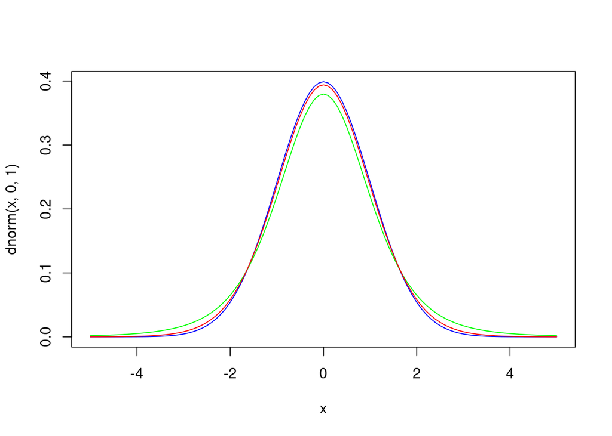

```r
curve(dnorm(x,0,1), from = -5, to = 5, col = "blue")
curve(dt(x,5), add = T, col = "green")
curve(dt(x,20), add = T, col = "red")
```

## 2.2 Con matrices de covarianzas

Tenemos que

$$\hat{\beta}_a \rightarrow N(\beta_a, \sigma^2 Q_a)$$

donde

$$Q_a = \frac{1}{n-1}S_{XX}^{-1}$$

Esto implica que:

$$\hat \beta_i \rightarrow N(\beta_i, \sigma^2 Q_{a(i,i)}), \quad i = 1,2,
\ldots,k$$

donde $Q_{a(i,j)}$ es el elemento *(i,j)* de la matriz $Q_a$. Por tanto, siguiendo el razonamiento del apartado anterior:

$$se(\hat \beta_i) = \sqrt{ \hat s_R^2 Q_{a(i,i)}}, \quad i = 1,2,\cdots,k$$

Para $\hat \beta_0$ tenemos que

$$\hat \beta_0 \sim N \left( \beta_0, \sigma^2 \left( \frac{1}{n} +
\frac{1}{n-1} \bar x^T S_{XX}^{-1} \bar x \right) \right)$$

Por tanto

$$se(\hat \beta_0) = \sqrt{\hat s_R^2 \left( \frac{1}{n} + \frac{1}{n-1}
\bar x^T S_{XX}^{-1} \bar x \right) }$$

Finalmente, el intervalo de confianza $100(1-\alpha)$% se obtiene como

$$\hat \beta_i \pm t_{n-k-1;\alpha/2} se(\hat \beta_i), \quad i =
0,1,2,\cdots,k.$$

# 3 Intervalo de confianza para $\sigma^2$

Partimos de la distribución en el muestreo:

$$\frac{(n-k-1)\hat s_R^2}{\sigma^2} \rightarrow \chi^2_{n-k-1}$$

Despejando:

$$\frac{(n-k-1)\hat s_R^2}{\chi^2_{n-k-1;\alpha/2}} \leq \sigma^2 \leq
\frac{(n-k-1)\hat s_R^2}{\chi^2_{n-k-1;1-\alpha/2}}$$
Podemos dibujar la distribución $\chi^2$:

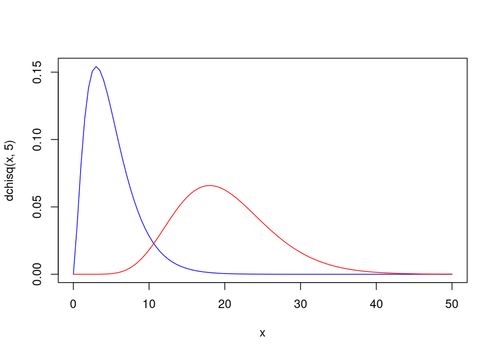

```r
curve(dchisq(x,5), from = 0, to =50, col = "blue")
curve(dchisq(x,20), add = T, col = "red")
```

# 4 Ejemplo

Vamos a calcular de manera detallada los intervalos de confianza para el modelo *kid_score ~ mom_iq + mom_hs*:

```r
d = read.csv("datos/kidiq.csv")
#d$mom_hs = factor(d$mom_hs, labels = c("no", "si"))
```

```r
m = lm(kid_score ~ mom_iq + mom_hs, data = d)
```

Los parámetros estimados son:

```r
coef(m)
```

```
## (Intercept)      mom_iq      mom_hs
##   25.731538    0.563906    5.950117
```

```r
# varianza residual
n = nrow(d)
k = 2 # numero de regresores
(sR2 = sum(resid(m)^2)/(n-k-1))
```

```
## [1] 328.9028
```

Vamos a calcular la varianza de los parámetros estimados, es decir $var(\hat \beta_i) = \hat s_R^2 Q_{i+1,i+1}$:

```r
X = cbind(rep(1,n), d$mom_iq, d$mom_hs)
# Q = inv(t(X)*X)
(Q = solve(crossprod(X))) # crossprod es otra manera de calcular t(X) %*% X
```

```
##               [,1]          [,2]          [,3]
## [1,]  0.1049491626 -1.025110e-03 -0.0001705848
## [2,] -0.0010251098  1.115594e-05 -0.0001151616
## [3,] -0.0001705848 -1.151616e-04  0.0148740410
```

Por tanto, la matriz de varianzas de los estimadores será

```r
(beta_var = sR2 * Q)
```

```
##             [,1]         [,2]        [,3]
## [1,] 34.51806922 -0.337161456 -0.05610582
## [2,] -0.33716146  0.003669219 -0.03787697
## [3,] -0.05610582 -0.037876974  4.89211314
```

Y el standard error de los estimadores, $se(\hat \beta_i)$:

```r
(beta_se = sqrt(diag(beta_var)))
```

```
## [1] 5.87520802 0.06057408 2.21181218
```

Vamos a calcular ahora el standard error de los estimadores con la matriz de varianzas de los regresores:

```r
Xa = cbind(d$mom_iq, d$mom_hs)
(Qa = 1/(n-1)*solve(var(Xa)))
```

```
##               [,1]          [,2]
## [1,]  1.115594e-05 -0.0001151616
## [2,] -1.151616e-04  0.0148740410
```

El standard error de los estimadores $\hat\beta_1$ y $\hat \beta_2$ son:

```r
sqrt(diag(Qa)*sR2)
```

```
## [1] 0.06057408 2.21181218
```

Para $\hat \beta_0$:

```r
( xmed = matrix(colMeans(Xa), ncol = 1) )
```

```
##             [,1]
## [1,] 100.0000000
## [2,]   0.7857143
```

```r
sqrt( sR2*(1/n + 1/(n-1)*t(xmed) %*% solve(var(Xa)) %*% xmed ) )
```

```
##          [,1]
## [1,] 5.875208
```

Por último, R dispone de una función para calcular la matriz de varianzas de los parámetros estimados, es decir $var(\hat \beta) = Q_{ii} \hat s_R^2$, mediante:

```r
vcov(m)
```

```
##             (Intercept)       mom_iq      mom_hs
## (Intercept) 34.51806922 -0.337161456 -0.05610582
## mom_iq      -0.33716146  0.003669219 -0.03787697
## mom_hs      -0.05610582 -0.037876974  4.89211314
```

Por tanto, el standard error de los estimadores será

```r
sqrt(diag(vcov(m)))
```

```
## (Intercept)      mom_iq      mom_hs
##  5.87520802  0.06057408  2.21181218
```

Como vemos, los tres métodos dan el mismo resultado.

El valor de la t con n-k-1 = 431 grados de libertad es

```r
(t1 = qt(1-0.05/2, df = n-k-1))
```

```
## [1] 1.965483
```

El límite inferior (LI) y el límite superior de los intervalos será:

```r
(LI = coef(m) - qt(1-0.05/2, df = n-k-1)*beta_se)
```

```
## (Intercept)      mom_iq      mom_hs
##  14.1839148   0.4448487   1.6028370
```

```r
(LS = coef(m) + qt(1-0.05/2, df = n-k-1)*beta_se)
```

```
## (Intercept)      mom_iq      mom_hs
##  37.2791615   0.6829634  10.2973969
```

Si lo juntamos todo en una tabla

```r
data.frame(estimacion = coef(m), se = beta_se, LI, LS)
```

```
##             estimacion         se         LI         LS
## (Intercept)  25.731538 5.87520802 14.1839148 37.2791615
## mom_iq        0.563906 0.06057408  0.4448487  0.6829634
## mom_hs        5.950117 2.21181218  1.6028370 10.2973969
```

Directamente, mediante la función *confint()* de R se pueden obtener dichos valores:

```r
confint(m)
```

```
##                  2.5 %     97.5 %
## (Intercept) 14.1839148 37.2791615
## mom_iq       0.4448487  0.6829634
## mom_hs       1.6028370 10.2973969
```

Si queremos otro nivel de confianza, por ejemplo, 90%:

```r
confint(m, level = 0.90)
```

```
##                    5 %       95 %
## (Intercept) 16.0468646 35.4162117
## mom_iq       0.4640559  0.6637562
## mom_hs       2.3041730  9.5960608
```

- En el caso de la varianza del modelo. Su estimador es:

```r
sR2
```

```
## [1] 328.9028
```

Y su intervalo de confianza:

```r
c((n-k-1)*sR2/qchisq(1-0.05/2, df = n-k-1), (n-k-1)*sR2/qchisq(0.05/2, df = n-k-1))
```

```
## [1] 289.0557 377.6434
```